# LAB 1

Daniel Rodan & Ido Shalom

2023-06-08

### Loading data and basic processing:

**1.a.**

```r
democracy <- read_html("https://en.wikipedia.org/wiki/Democracy_Index")
all.tables = html_nodes(democracy, "table")

# Use html_table to extract the individual tables from the all.tables object:
DF_Regions <- as.data.frame(html_table(all.tables[4], fill = TRUE))
DF_Countries <- as.data.frame(html_table(all.tables[6], fill = TRUE))
DF_Components <- as.data.frame(html_table(all.tables[7], fill = TRUE))

# Clean the Components data
DF_Components <- DF_Components[-c(1:2),]
DF_Components <- DF_Components[-25,]
DF_Components <- DF_Components[-73,]
DF_Components <- DF_Components[-109,]
DF_Components <- DF_Components[,-2]

# Change Components column names
colnames(DF_Components)[colnames(DF_Components) == "Elec.toral.pro.cessand.plura.lism"] <- "Electoral_Process_and_Pluralism"
colnames(DF_Components)[colnames(DF_Components) == "Func.tioningof.govern.ment"] <- "Functioning_of_Government"
colnames(DF_Components)[colnames(DF_Components) == "Poli.ticalpartici.pation"] <- "Political_Participation"
colnames(DF_Components)[colnames(DF_Components) == "Poli.ticalcul.ture"] <- "Political_Culture"
colnames(DF_Components)[colnames(DF_Components) == "Civilliber.ties"] <- "Civil_Liberties"

# Change the columns from char to double
DF_Components$Electoral_Process_and_Pluralism <- as.numeric(DF_Components$Electoral_Process_and_Pluralism)
DF_Components$Overall.score <- as.numeric(DF_Components$Overall.score)
DF_Components$Functioning_of_Government <- as.numeric(DF_Components$Functioning_of_Government)
DF_Components$Political_Culture <- as.numeric(DF_Components$Political_Culture)
DF_Components$Political_Participation<- as.numeric(DF_Components$Political_Participation)
DF_Components$Civil_Liberties <- as.numeric(DF_Components$Civil_Liberties)

# Change Regions column names
colnames(DF_Regions)[colnames(DF_Regions) == "Coun.tries"] <- "Number_of_Countries"

# Display the top 5 rows for each table
head(DF_Regions)
```

|  | Region | Number_of_Countries | X2022 | X2021 | X2020 | X2019 | X2018 | X2017 | X2016 | X2015 | X2014 | X2013 | X2012 | X2011 | X2010 | X2008 | X2006 |
| --- | --- | --- | --- | --- | --- | --- | --- | --- | --- | --- | --- | --- | --- | --- | --- | --- | --- |
| 1 | North America | 2 | 8.37 | 8.36 | 8.58 | 8.59 | 8.56 | 8.56 | 8.56 | 8.56 | 8.59 | 8.59 | 8.59 | 8.59 | 8.63 | 8.64 | 8.64 |
| 2 | Western Europe | 21 | 8.36 | 8.23 | 8.29 | 8.35 | 8.35 | 8.38 | 8.40 | 8.42 | 8.41 | 8.41 | 8.44 | 8.40 | 8.45 | 8.61 | 8.60 |
| 3 | Latin America and the Caribbean | 24 | 5.79 | 5.83 | 6.09 | 6.13 | 6.24 | 6.26 | 6.33 | 6.37 | 6.36 | 6.38 | 6.36 | 6.35 | 6.37 | 6.43 | 6.37 |
| 4 | Asia and Australasia | 28 | 5.46 | 5.46 | 5.62 | 5.67 | 5.67 | 5.63 | 5.74 | 5.74 | 5.70 | 5.61 | 5.56 | 5.51 | 5.53 | 5.58 | 5.44 |
| 5 | Central and Eastern Europe | 28 | 5.39 | 5.36 | 5.36 | 5.42 | 5.42 | 5.40 | 5.43 | 5.55 | 5.58 | 5.53 | 5.51 | 5.50 | 5.55 | 5.67 | 5.76 |
| 6 | Sub-Saharan Africa | 44 | 4.14 | 4.12 | 4.16 | 4.26 | 4.36 | 4.35 | 4.37 | 4.38 | 4.34 | 4.36 | 4.33 | 4.32 | 4.23 | 4.28 | 4.24 |

```r
head(DF_Countries)
```

|  | Region | X2022.rank | Country | Regime.type | X2022 | X2021 | X2020 | X2019 | X2018 | X2017 | X2016 | X2015 | X2014 | X2013 | X2012 | X2011 | X2010 | X2008 | X2006 |
| --- | --- | --- | --- | --- | --- | --- | --- | --- | --- | --- | --- | --- | --- | --- | --- | --- | --- | --- | --- |
| 1 | North America | 12 | Canada | Full democracy | 8.88 | 8.87 | 9.24 | 9.22 | 9.15 | 9.15 | 9.15 | 9.08 | 9.08 | 9.08 | 9.08 | 9.08 | 9.08 | 9.07 | 9.07 |
| 2 | North America | 30 | United States | Flawed democracy | 7.85 | 7.85 | 7.92 | 7.96 | 7.96 | 7.98 | 7.98 | 8.05 | 8.11 | 8.11 | 8.11 | 8.11 | 8.18 | 8.22 | 8.22 |
| 3 | Western Europe | 20 | Austria | Full democracy | 8.20 | 8.07 | 8.16 | 8.29 | 8.29 | 8.42 | 8.41 | 8.54 | 8.54 | 8.48 | 8.62 | 8.49 | 8.49 | 8.49 | 8.69 |
| 4 | Western Europe | 36 | Belgium | Flawed democracy | 7.64 | 7.51 | 7.51 | 7.64 | 7.78 | 7.78 | 7.77 | 7.93 | 7.93 | 8.05 | 8.05 | 8.05 | 8.05 | 8.16 | 8.15 |
| 5 | Western Europe | 37 | Cyprus | Flawed democracy | 7.38 | 7.43 | 7.56 | 7.59 | 7.59 | 7.59 | 7.65 | 7.53 | 7.40 | 7.29 | 7.29 | 7.29 | 7.29 | 7.70 | 7.60 |
| 6 | Western Europe | 6 | Denmark | Full democracy | 9.28 | 9.09 | 9.15 | 9.22 | 9.22 | 9.22 | 9.20 | 9.11 | 9.11 | 9.38 | 9.52 | 9.52 | 9.52 | 9.52 | 9.52 |

```r
head(DF_Components)
```

|  | Rank | Country | Regime.type | Overall.score | Δ.Score | Electoral_Process_and_Pluralism | Functioning_of_Government | Political_Participation | Political_Culture | Civil_Liberties |
| --- | --- | --- | --- | --- | --- | --- | --- | --- | --- | --- |
| 3 | 1 | Norway | Full democracy | 9.81 | 0.06 | 10.00 | 9.64 | 10.00 | 10.00 | 9.41 |
| 4 | 2 | New Zealand | Full democracy | 9.61 | 0.14 | 10.00 | 9.29 | 10.00 | 8.75 | 10.00 |
| 5 | 3 | Iceland | Full democracy | 9.52 | 0.34 | 10.00 | 9.64 | 8.89 | 9.38 | 9.71 |
| 6 | 4 | Sweden | Full democracy | 9.39 | 0.13 | 9.58 | 9.64 | 8.33 | 10.00 | 9.41 |
| 7 | 5 | Finland | Full democracy | 9.29 | 0.02 | 10.00 | 9.64 | 8.33 | 8.75 | 9.71 |
| 8 | 6 | Denmark | Full democracy | 9.28 | 0.19 | 10.00 | 9.29 | 8.33 | 9.38 | 9.41 |

**1.b.**

```r
# The top 5 countries by democracy index in 2022
Top5_by_DI <- DF_Countries %>%
  select(Country, X2022)%>%
  slice_max(order_by = DF_Countries$X2022, n=5)
Top5_by_DI
```

| Country | X2022 |
| --- | --- |
| Norway | 9.81 |
| New Zealand | 9.61 |
| Iceland | 9.52 |
| Sweden | 9.39 |
| Finland | 9.29 |

```r
# The bottom 5 countries by democracy index in 2022
Bottom5_by_DI <- DF_Countries %>%
  select(Country, X2022)%>%
  slice_min(order_by = DF_Countries$X2022, n=5)
Bottom5_by_DI
```

| Country | X2022 |
| --- | --- |
| Afghanistan | 0.32 |
| Myanmar | 0.74 |
| North Korea | 1.08 |
| Central African Republic | 1.35 |
| Syria | 1.43 |

```r
# Add the AVG_Index for each country
DF_Countries$AVG_Index <- round(rowMeans(DF_Countries[,5:19], na.rm = TRUE), digits = 3)

# The top 5 countries by  avg democracy index in 2022
Top5_by_ADI <- DF_Countries %>%
  select(Country, AVG_Index)%>%
  slice_max(order_by = DF_Countries$AVG_Index, n=5)
Top5_by_ADI
```

| Country | AVG_Index |
| --- | --- |
| Norway | 9.831 |
| Iceland | 9.562 |
| Sweden | 9.525 |
| Denmark | 9.305 |
| New Zealand | 9.269 |

```r
# The bottom 5 countries by avg democracy index in 2022
Bottom5_by_ADI <- DF_Countries %>%
  select(Country, AVG_Index)%>%
  slice_min(order_by = DF_Countries$AVG_Index, n=5)
Bottom5_by_ADI
```

| Country | AVG_Index |
| --- | --- |
| North Korea | 1.062 |
| Chad | 1.569 |
| Central African Republic | 1.581 |
| Syria | 1.701 |
| Turkmenistan | 1.741 |

### Plotting distributions of groups of countries:

**2.a.**

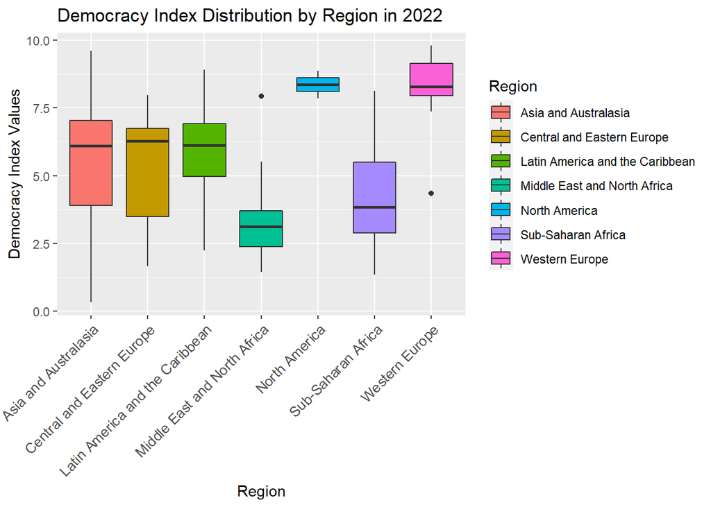

```r
# Create a boxplot for democracy index by region in 2022
DI_dist_plot_2022<- ggplot(DF_Countries, aes(x=Region, y=X2022, fill=Region)) +
    geom_boxplot() +
    labs (x="Region", y="Democracy Index Values")+
    ggtitle("Democracy Index Distribution by Region in 2022")+
    theme(axis.text.x = element_text(angle = 45, hjust = 1, size = 10))

# Display the boxplot
DI_dist_plot_2022
```

```r
# Extract the outlier observations
boxplot_data <- layer_data(DI_dist_plot_2022, 1)
outliers <- boxplot_data$outliers

# Filter the data based on outlier values
outlier_observations <- DF_Countries[DF_Countries$X2022 %in% outliers, ]

# Display the identified outlier observations
outlier_observations[,c(1,3,5)]
```

|  | Region | Country | X2022 |
| --- | --- | --- | --- |
| 22 | Western Europe | Turkey | 4.35 |
| 109 | Middle East and North Africa | Israel | 7.93 |

**2.b.**

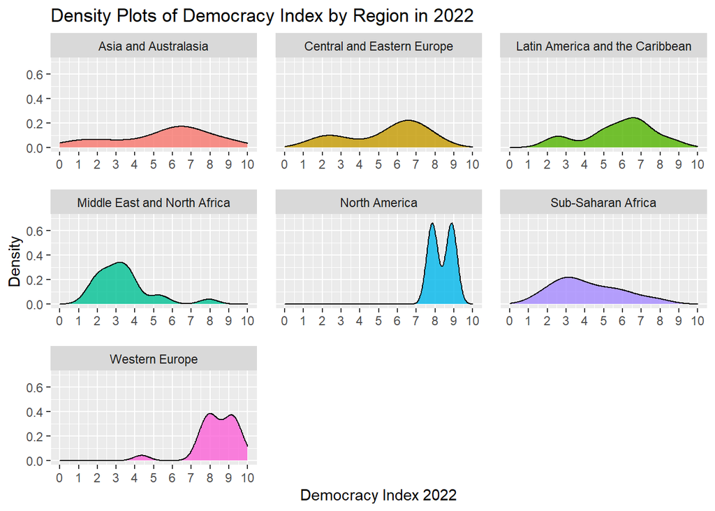

```r
# Create density plots for democracy index by region in 2022
dp <- ggplot(DF_Countries, aes(x = X2022, fill = Region)) +
  geom_density(alpha = 0.8) +
  labs(x = "Democracy Index 2022", y = "Density") +
  ggtitle("Density Plots of Democracy Index by Region in 2022") +
  scale_fill_discrete(guide="none")+
  facet_wrap(~ Region, nrow =3, scales = "free_x")+
  scale_x_continuous(limits = c(0, 10), breaks = c(0,1,2,3,4,5,6,7,8,9,10))+
  scale_y_continuous(limits = c(0, 0.7))+
  theme(panel.spacing = unit(0.9, "lines"))

# Display the plots
dp
```

The density that might be looking like the normal distribution, is the one for Sub-Saharan Africa. There are other more densities that might look like it as well, like Middle East & North Africa and Western Europe, if we ignore the outlier, they look like a shifted normal distribution ($\mu \neq 0$).

```r
# Create a statistics table for each region
region_statistics <- DF_Countries %>%
  group_by(Region) %>%
  summarize(
    Mean = mean(X2022),
    Variance = var(X2022),
    Skewness = skewness(X2022),
    Kurtosis = kurtosis(X2022)
  )
# Display the statistics table
region_statistics
```

| Region | Mean | Variance | Skewness | Kurtosis |
| --- | --- | --- | --- | --- |
| Asia and Australasia | 5.461786 | 6.681363 | -0.5293145 | 2.321449 |
| Central and Eastern Europe | 5.390000 | 4.232007 | -0.6491559 | 1.993328 |
| Latin America and the Caribbean | 5.791250 | 3.398785 | -0.5038192 | 2.517328 |
| Middle East and North Africa | 3.342000 | 2.215206 | 1.5421823 | 5.653633 |
| North America | 8.365000 | 0.530450 | 0.0000000 | 1.000000 |
| Sub-Saharan Africa | 4.138182 | 3.178936 | 0.5061760 | 2.373718 |
| Western Europe | 8.355714 | 1.359536 | -1.8604063 | 7.641148 |

From the mean we can learn that Europe & North America are the most democratic regions and Middle East and North Africa and Sub-Saharan Africa are the least democratic regions.

The highest variance is for Asia and Australia region, so we can infer that it’s mean statistics might not be so significant, it either be a relatively democratic region but also could be a non-democratic one.

By the Skewness, it is clear most of the regions have a left tail which indicates asymmetrical distribution with more smaller and further values from the mean. On North America, the skewness is zero and that is because it has only two countries (so they will be always perfectly symmetrical to the mean).

Note: by looking of all the statistics values, we might tend to think that North America has a shifted normal distribution, but because we are looking only on two observations, we can not assume that.

### Comparing countries and showing trends in democracy index:

**3.a.**

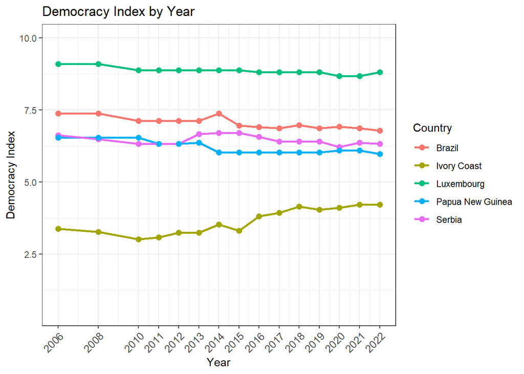

```r
plot_democracy_index <- function(data, countries) {
  # Filter the data for the specified countries
  filtered_data <- data %>%
    filter(Country %in% countries)

   # Select the desired columns
  selected_columns <- names(filtered_data)[5:19]

  # Pivot the data
  data_long <- pivot_longer(filtered_data, cols = all_of(selected_columns), names_to = "Year", values_to = "DemocracyIndex")

  # Convert Year to numeric
  data_long$Year <- as.numeric(substring(data_long$Year, 2))

  # A plot for the DI for each country
  plot <- ggplot(data_long, aes(x = Year, y = DemocracyIndex, color = Country, group = Country)) +
    geom_line(size = 1) +
    geom_point(size = 2.3, shape = 19) +
    labs(x = "Year", y = "Democracy Index", title = "Democracy Index by Year") +
    scale_x_continuous(limits = c(2006, 2022), breaks = c(2006,2008,2010,2011,2012,2013,2014,2015,
                                                          2016,2017,2018,2019,2020,2021,2022))+
    scale_y_continuous(limits = c(0.5, 10))+
    theme_bw() +
    theme(legend.position = "right", axis.text.x = element_text(angle = 45, hjust = 1, size = 10))

  print(plot)
}

# Display the plot with 5 countries of our choice
plot_democracy_index(DF_Countries, c("Brazil", "Papua New Guinea", "Serbia", "Ivory Coast", "Luxembourg"))
```

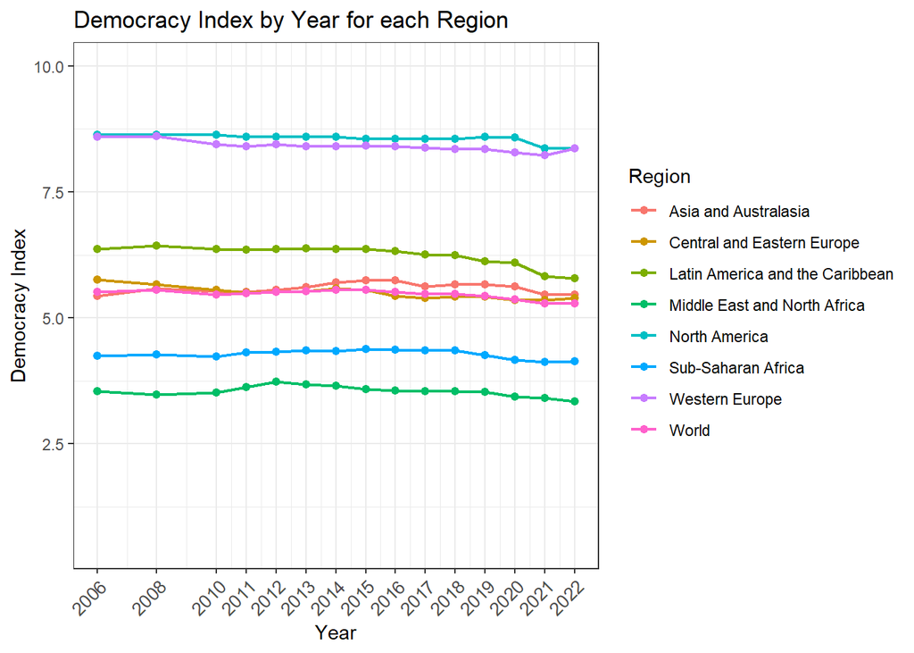

```r
plot_democracy_index_regions <- function(data, regions) {
  # Filter the data for the specified countries
  filtered_data <- data %>%
    filter(Region %in% regions)

   # Select the desired columns
  selected_columns <- names(filtered_data)[3:17]

  # Pivot the data
  data_long <- pivot_longer(filtered_data, cols = all_of(selected_columns), names_to = "Year", values_to = "DemocracyIndex")

  # Convert Year to numeric
  data_long$Year <- as.numeric(substring(data_long$Year, 2))

  # A plot for the DI for each country
  regions_DI_plot <- ggplot(data_long, aes(x = Year, y = DemocracyIndex, color = Region, group = Region)) +
    geom_line(size = 0.8) +
    geom_point(size = 1.7, shape = 19) +
    labs(x = "Year", y = "Democracy Index", title = "Democracy Index by Year for each Region") +
    scale_x_continuous(limits = c(2006, 2022), breaks = c(2006,2008,2010,2011,2012,2013,2014,2015,
                                                          2016,2017,2018,2019,2020,2021,2022))+
    scale_y_continuous(limits = c(0.5, 10))+
    theme_bw() +
    theme(legend.position = "right", axis.text.x = element_text(angle = 45, hjust = 1, size = 10))

  print(regions_DI_plot)
}

# Display the plot for regions
plot_democracy_index_regions(DF_Regions, DF_Regions$Region)
```

**3.b.**

```r
# Calculate the index change for each country between 2006 and 2022
index_change <- DF_Countries$X2022 - DF_Countries$X2006

# Create a new column in DF_Countries to represent the cluster
DF_Countries$Cluster <- NA

# clusters 1-2: Countries that their DI increased/decreased by at least 1.5
DF_Countries$Cluster[index_change >= 1.5] <- "Large Increase"
DF_Countries$Cluster[index_change <= -1.5] <- "Large Decrease"

# clusters 3-4: Countries that their DI increased/decreased by [0.75-1.5]
DF_Countries$Cluster[index_change >= 0.75 & index_change < 1.5] <- "Moderate Increase"
DF_Countries$Cluster[index_change <= -0.75 & index_change > -1.5] <- "Moderate Decrease"

# adding a new minimum value column
DF_Countries <- DF_Countries %>%
  mutate(Minimum_DI = apply(.[, 5:19], 1, min))

# adding a new maximum value column
DF_Countries <- DF_Countries %>%
  mutate(Maximum_DI = apply(.[, 5:19], 1, max))

# Creating helpers for clusters 5 & 6
min_change_2022 <- DF_Countries$X2022 - DF_Countries$Minimum_DI
min_change_2006 <- DF_Countries$X2006 - DF_Countries$Minimum_DI
max_change_2022 <- DF_Countries$Maximum_DI - DF_Countries$X2022
max_change_2006 <- DF_Countries$Maximum_DI - DF_Countries$X2006

#cluster 5:Countries that decreased by at least 0.75 points after 2006 and then increased by at least 0.75 points in 2022 compared to the lowest point
DF_Countries$Cluster[min_change_2006 >= 0.75 & min_change_2022 >= 0.75 & is.na(DF_Countries$Cluster)] <- "Recovery"

# Cluster 6: Countries that increased by at least 0.75 points after 2006 and then dropped by at least 0.75 points in 2022 compared to the highest point
DF_Countries$Cluster[max_change_2006 >= 0.75 & max_change_2022 >= 0.75 & is.na(DF_Countries$Cluster)] <- "Decline"

# Creating helper for cluster 7
max_min_diff <- DF_Countries$Maximum_DI - DF_Countries$Minimum_DI

# Cluster 7: Countries that had barely changed from 2006 to 2022
DF_Countries$Cluster[max_min_diff < 0.5 & is.na(DF_Countries$Cluster)] <- "Barely Changed"

# Cluster 8: All other countries
DF_Countries$Cluster[is.na(DF_Countries$Cluster)] <- "Other"
```

```r
# Creating a new DF, for the avg vakues for each cluster
DF_cluster<- aggregate(DF_Countries[, 5:19], by = list(Cluster = DF_Countries$Cluster), FUN = mean, na.rm = TRUE)

# Display a DF for all clusters
DF_cluster
```

| Cluster | X2022 | X2021 | X2020 | X2019 | X2018 | X2017 | X2016 | X2015 | X2014 | X2013 | X2012 | X2011 | X2010 | X2008 | X2006 |
| --- | --- | --- | --- | --- | --- | --- | --- | --- | --- | --- | --- | --- | --- | --- | --- |
| Barely Changed | 6.559143 | 6.505429 | 6.527429 | 6.575429 | 6.554857 | 6.534571 | 6.567143 | 6.577143 | 6.570286 | 6.558571 | 6.536000 | 6.514286 | 6.502857 | 6.569143 | 6.557429 |
| Decline | 3.248571 | 3.281429 | 3.501429 | 3.697143 | 3.932857 | 4.012857 | 4.041429 | 4.207143 | 4.198571 | 4.260000 | 4.104286 | 3.732857 | 3.362857 | 3.185714 | 3.264286 |
| Large Decrease | 3.057692 | 3.170769 | 3.612308 | 3.793846 | 3.975385 | 4.136154 | 4.306923 | 4.467692 | 4.595385 | 4.666923 | 4.690000 | 4.866154 | 4.988462 | 5.278462 | 5.336923 |
| Large Increase | 5.003333 | 5.023333 | 5.320000 | 5.246667 | 5.110000 | 5.006667 | 4.910000 | 5.000000 | 4.843333 | 4.643333 | 4.556667 | 4.473333 | 3.596667 | 3.536667 | 2.696667 |
| Moderate Decrease | 3.550870 | 3.699565 | 3.922174 | 4.020435 | 4.261739 | 4.297391 | 4.406522 | 4.424348 | 4.395217 | 4.414348 | 4.453913 | 4.423913 | 4.443913 | 4.585652 | 4.622609 |
| Moderate Increase | 5.663571 | 5.569286 | 5.540000 | 5.497143 | 5.258571 | 5.143571 | 5.146429 | 5.126429 | 5.105714 | 5.168571 | 5.134286 | 5.055714 | 5.019286 | 4.872143 | 4.558571 |
| Other | 5.775606 | 5.728333 | 5.748182 | 5.821212 | 5.850606 | 5.836364 | 5.887576 | 5.895758 | 5.899545 | 5.868333 | 5.854848 | 5.813788 | 5.802121 | 5.866818 | 5.854545 |
| Recovery | 5.790000 | 5.651667 | 5.618333 | 5.618333 | 5.530000 | 5.460000 | 5.175000 | 5.326667 | 5.160000 | 4.838333 | 4.811667 | 4.978333 | 5.001667 | 5.686667 | 5.891667 |

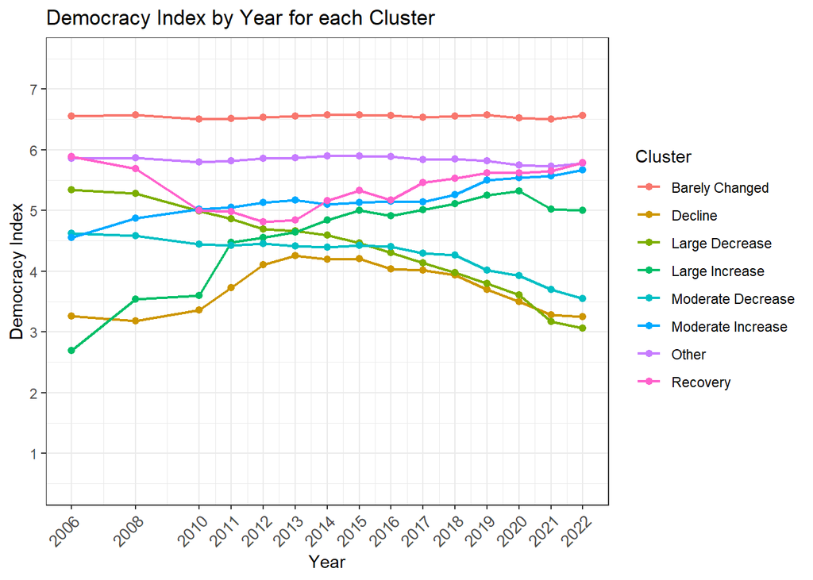

```r
plot_democracy_index_clusters <- function(data, Clusters) {
  # Filter the data for the specified countries
  filtered_data <- data %>%
    filter(Cluster %in% Clusters)

   # Select the desired columns
  selected_columns <- names(filtered_data)[2:16]

  # Pivot the data
  data_long <- pivot_longer(filtered_data, cols = all_of(selected_columns), names_to = "Year", values_to = "DemocracyIndex")

  # Convert Year to numeric
  data_long$Year <- as.numeric(substring(data_long$Year, 2))

  # A plot for the DI for each country
  clusters_DI_plot <- ggplot(data_long, aes(x = Year, y = DemocracyIndex, color = Cluster, group = Cluster)) +
    geom_line(size = 0.8) +
    geom_point(size = 1.7, shape = 19) +
    labs(x = "Year", y = "Democracy Index", title = "Democracy Index by Year for each Cluster") +
    scale_x_continuous(limits = c(2006, 2022), breaks = c(2006,2008,2010,2011,2012,2013,2014,2015,
                                                          2016,2017,2018,2019,2020,2021,2022))+
    scale_y_continuous(limits = c(0.5, 7.5), breaks = c(1,2,3,4,5,6,7))+
    theme_bw() +
    theme(legend.position = "right", axis.text.x = element_text(angle = 45, hjust = 1, size = 10))

  print(clusters_DI_plot)
}

# Display the plot for each cluster
plot_democracy_index_clusters(DF_cluster, DF_cluster$Cluster)
```

As expected, for the barely changed the graph is relevantly static. Plus, the graphs of large & moderate increase and large & moderate decrease fits well, and showing the trend in a good way. The recovery and decline, also work well when the first drops and then rise and the other rise and then drops back.

### Change in category:

**4.**

```r
# Create a new column in DF_Countries to represent the regime type in 2006
DF_Countries$Regime.type.2006 <- NA

# Categorize each regime type by it's values
DF_Countries$Regime.type.2006[DF_Countries$X2006 <= 4] <- "Authoritarian"
DF_Countries$Regime.type.2006[DF_Countries$X2006 > 4 & DF_Countries$X2006 <= 6] <- "Hybrid regime"
DF_Countries$Regime.type.2006[DF_Countries$X2006 > 6 & DF_Countries$X2006 <= 8] <- "Flawed democracy"
DF_Countries$Regime.type.2006[DF_Countries$X2006 > 8] <- "Full democracy"

# Create a vector of distinct regime type names
regime_types <- c("Full democracy", "Flawed democracy", "Hybrid regime", "Authoritarian")

# Create a new matrix to store the estimated probabilities
probabilities <- matrix(0, nrow = length(regime_types), ncol = length(regime_types))
colnames(probabilities) <- regime_types
rownames(probabilities) <- regime_types

# go through each regime type
for (i in regime_types) {
  # Subset the data for the specific regime type in 2006
  subset_2006 <- DF_Countries[DF_Countries$Regime.type.2006 == i, ]
  # Count the number of countries in each regime type in 2022
  counts_2022 <- table(subset_2006$Regime.type)
  # Calculate the probabilities
  probabilities[i, names(counts_2022)] <- counts_2022 / sum(counts_2022)
}

# Display the probabilities as data frame
DF_probabilities <- as.data.frame(probabilities)
DF_probabilities
```

|  | Full democracy | Flawed democracy | Hybrid regime | Authoritarian |
| --- | --- | --- | --- | --- |
| Full democracy | 0.7692308 | 0.2307692 | 0.0000000 | 0.00000000 |
| Flawed democracy | 0.0754717 | 0.6981132 | 0.2075472 | 0.01886792 |
| Hybrid regime | 0.0000000 | 0.1515152 | 0.4848485 | 0.36363636 |
| Authoritarian | 0.0000000 | 0.0000000 | 0.1636364 | 0.83636364 |

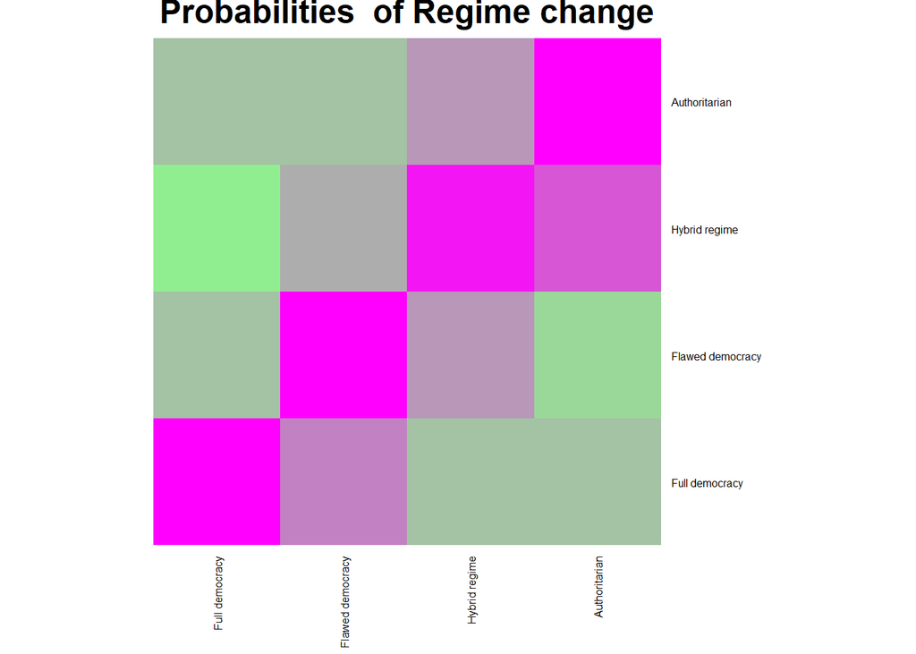

```r
# Display the heat map
heatmap(probabilities, col = colorRampPalette(c("lightgreen", "magenta"))(12),Colv = NA, Rowv = NA, main = "Probabilities  of Regime change", cexRow = 0.615, cexCol = 0.615)
```

### Joining data from additional tables:

**5.a.**

```r
# All the tables from the GDP Wikipedia page
GDP <- read_html("https://en.wikipedia.org/wiki/List_of_countries_by_GDP_(PPP)_per_capita")
all.tables.GDP = html_nodes(GDP, "table")

# All the tables from the pop size Wikipedia page
pop_size <- read_html("https://en.wikipedia.org/wiki/List_of_countries_and_dependencies_by_population")
all.tables.pop = html_nodes(pop_size, "table")

# All the tables from the crime rate Wikipedia page
crime_rate <- read_html("https://en.wikipedia.org/wiki/List_of_countries_by_incarceration_rate")
all.tables.crime = html_nodes(crime_rate, "table")

# All the tables from the area Wikipedia page
area <- read_html("https://en.wikipedia.org/wiki/List_of_countries_and_dependencies_by_area")
all.tables.area = html_nodes(area, "table")

# Extract the tables for countries into a relevant data frames
DF_GDP <- as.data.frame(html_table(all.tables.GDP[2], fill = TRUE))
DF_pop_size <- as.data.frame(html_table(all.tables.pop[2], fill = TRUE))
DF_crime_rate <- as.data.frame(html_table(all.tables.crime[2], fill = TRUE))
DF_area <- as.data.frame(html_table(all.tables.area[2], fill = TRUE))

# Clean the GDP data
DF_GDP <- DF_GDP[-1,]
DF_GDP$Country.Territory <- gsub("\\*$", "", DF_GDP$Country.Territory)
colnames(DF_GDP)[colnames(DF_GDP) == "Country.Territory"] <- "Country"
colnames(DF_GDP)[colnames(DF_GDP) == "IMF.5..6."] <- "IMF_Estimate"
colnames(DF_GDP)[colnames(DF_GDP) == "IMF.5..6..1"] <- "IMF_Year"
colnames(DF_GDP)[colnames(DF_GDP) == "World.Bank.7."] <- "World_Bank_Estimate"
colnames(DF_GDP)[colnames(DF_GDP) == "World.Bank.7..1"] <- "World_Bank_Year"
colnames(DF_GDP)[colnames(DF_GDP) == "CIA.8..9..10."] <- "CIA_Estimate"
colnames(DF_GDP)[colnames(DF_GDP) == "CIA.8..9..10..1"] <- "CIA_Year"
DF_GDP$Country <- gsub("\\s*\\([^)]+\\)", "", DF_GDP$Country)
DF_GDP$Country <- gsub("\\*\\[n \\d+\\]$", "", DF_GDP$Country)

# Clean the population data
DF_pop_size <- DF_pop_size[-1,]
DF_pop_size <- DF_pop_size[, !(names(DF_pop_size) == "Notes")]
colnames(DF_pop_size)[colnames(DF_pop_size) == "Country...Dependency"] <- "Country"
colnames(DF_pop_size)[colnames(DF_pop_size) == "Rank"] <- "Rank_Pop"
colnames(DF_pop_size)[colnames(DF_pop_size) == "Population"] <- "Pop_Number"
colnames(DF_pop_size)[colnames(DF_pop_size) == "Population.1"] <- "Pop_%"
colnames(DF_pop_size)[colnames(DF_pop_size) == "Source..official.or.from.the.United.Nations."] <- "Source"
DF_pop_size$Source <- sub("\\[\\d+\\]$", "", DF_pop_size$Source)
DF_pop_size$Country <- gsub("\\s*\\([^)]+\\)", "", DF_pop_size$Country)

# Clean the crime data
DF_crime_rate <- DF_crime_rate[-1,]
colnames(DF_crime_rate)[colnames(DF_crime_rate) == "Location"] <- "Country"
DF_crime_rate$Country <- gsub("\\*| \\[Note\\]$", "", DF_crime_rate$Country)
colnames(DF_crime_rate)[colnames(DF_crime_rate) == "Count.2."] <- "Crime_Number"
colnames(DF_crime_rate)[colnames(DF_crime_rate) == "Rate.per.100.000..3."] <- "Crime_Rate_per_100k"
colnames(DF_crime_rate)[colnames(DF_crime_rate) == "Male.....a."] <- "Male_%"
colnames(DF_crime_rate)[colnames(DF_crime_rate) == "Female.....4."] <- "Female_%"
colnames(DF_crime_rate)[colnames(DF_crime_rate) == "National.....b."] <- "National_%"
colnames(DF_crime_rate)[colnames(DF_crime_rate) == "Foreign.....5."] <- "Foreign_%"
colnames(DF_crime_rate)[colnames(DF_crime_rate) == "Occupancy.....6."] <- "Occupancy_%"
colnames(DF_crime_rate)[colnames(DF_crime_rate) == "Remand.....7."] <- "Remand_%"

# Clean the area data
DF_area <- DF_area[, !(names(DF_area) == "Notes")]
colnames(DF_area)[colnames(DF_area) == "Country...Dependency"] <- "Country"
DF_area$Country <- gsub("\\s*\\([^)]+\\)", "", DF_area$Country)
colnames(DF_area)[colnames(DF_area) == "Totalin.km2..mi2."] <- "Total_skm"
DF_area$Total_skm <- gsub("\\s*\\([^)]+\\)", "", DF_area$Total_skm)
DF_area$Total_skm <- gsub("<\\s", "", DF_area$Total_skm)
colnames(DF_area)[colnames(DF_area) == "Landin.km2..mi2."] <- "Land_skm"
DF_area$Land_skm <- gsub("\\s*\\([^)]+\\)", "", DF_area$Land_skm)
DF_area$Land_skm <- gsub("<", "", DF_area$Land_skm)
colnames(DF_area)[colnames(DF_area) == "Waterin.km2..mi2."] <- "Water_skm"
DF_area$Water_skm <- gsub("\\s*\\([^)]+\\)", "", DF_area$Water_skm)
colnames(DF_area)[colnames(DF_area) == "X.water"] <- "Water_%"
colnames(DF_area)[colnames(DF_area) == "Rank"] <- "Rank_area"

# more cleaning
DF_GDP$Country <- gsub("\\ ", "", DF_GDP$Country)
DF_GDP$Country <- gsub("\\*", "", DF_GDP$Country)

# more cleaning
DF_crime_rate$Country <-gsub("\\ ", "", DF_crime_rate$Country)
DF_crime_rate$Country <-gsub("\\*", "", DF_crime_rate$Country)
DF_crime_rate$Country <-gsub(" \\[Note]", "", DF_crime_rate$Country)

# Join the data frames (Do you wanna see me merge? [N.Kirel])
DF_merged <- merge(DF_Countries, DF_GDP, by = "Country", all = TRUE)
DF_merged <- merge(DF_merged, DF_crime_rate, by = "Country", all = TRUE)
DF_merged <- merge(DF_merged, DF_pop_size, by = "Country", all = TRUE)
DF_merged <- merge(DF_merged, DF_area, by = "Country", all = TRUE)

# Replace - values to NA
DF_merged[DF_merged == "—"] <- NA
DF_merged[DF_merged == "–"] <- NA

# Display the first rows of the DF
head(DF_merged)
```

|  | Country | Region.x | X2022.rank | Regime.type | X2022 | X2021 | X2020 | X2019 | X2018 | X2017 | X2016 | X2015 | X2014 | X2013 | X2012 | X2011 | X2010 | X2008 | X2006 | AVG_Index | Cluster | Minimum_DI | Maximum_DI | Regime.type.2006 | UN.Region | IMF_Estimate | IMF_Year | World_Bank_Estimate | World_Bank_Year | … |
| --- | --- | --- | --- | --- | --- | --- | --- | --- | --- | --- | --- | --- | --- | --- | --- | --- | --- | --- | --- | --- | --- | --- | --- | --- | --- | --- | --- | --- | --- | --- |
| 1 | Abkhazia | NA | NA | NA | NA | NA | NA | NA | NA | NA | NA | NA | NA | NA | NA | NA | NA | NA | NA | NA | NA | NA | NA | NA | NA | NA | NA | NA | NA | … |
| 2 | Afghanistan | Asia and Australasia | 167 | Authoritarian | 0.32 | 0.32 | 2.85 | 2.85 | 2.97 | 2.55 | 2.55 | 2.77 | 2.77 | 2.48 | 2.48 | 2.48 | 2.48 | 3.02 | 3.06 | 2.397 | Large Decrease | 0.32 | 3.06 | Authoritarian | Asia | 2,456 | 2020 | 1,666 | 2021 | … |
| 3 | Akrotiri and Dhekelia | NA | NA | NA | NA | NA | NA | NA | NA | NA | NA | NA | NA | NA | NA | NA | NA | NA | NA | NA | NA | NA | NA | NA | NA | NA | NA | NA | NA | … |
| 4 | Åland | NA | NA | NA | NA | NA | NA | NA | NA | NA | NA | NA | NA | NA | NA | NA | NA | NA | NA | NA | NA | NA | NA | NA | NA | NA | NA | NA | NA | … |
| 5 | Albania | Central and Eastern Europe | 64 | Flawed democracy | 6.41 | 6.11 | 6.08 | 5.89 | 5.98 | 5.98 | 5.91 | 5.91 | 5.67 | 5.67 | 5.67 | 5.81 | 5.86 | 5.91 | 5.91 | 5.918 | Other | 5.67 | 6.41 | Hybrid regime | Europe | 19,029 | 2023 | 15,709 | 2021 | … |
| 6 | Algeria | Middle East and North Africa | 113 | Authoritarian | 3.66 | 3.77 | 3.77 | 4.01 | 3.50 | 3.56 | 3.56 | 3.95 | 3.83 | 3.83 | 3.83 | 3.44 | 3.44 | 3.32 | 3.17 | 3.643 | Other | 3.17 | 4.01 | Authoritarian | Africa | 13,507 | 2023 | 12,128 | 2021 | … |

**5.b.**

```r
# Create a new mini DF for the two columns
DF_helper <- DF_merged[,c("CIA_Estimate", "X2022")]
DF_helper <- na.omit(DF_helper)

# change form a "characters" variables to "double" variables
DF_helper$New_CIA_Estimate <- as.numeric(gsub(",", "", DF_helper$CIA_Estimate))

# Create the linear regression for DI & GDP
DI_GDP_Reg <- lm(New_CIA_Estimate~X2022,data = DF_helper)
summary(DI_GDP_Reg)
```

```
##
## Call:
## lm(formula = New_CIA_Estimate ~ X2022, data = DF_helper)
##
## Residuals:
##    Min     1Q Median     3Q    Max
## -27624 -11755  -2982   7029  79827
##
## Coefficients:
##             Estimate Std. Error t value Pr(>|t|)
## (Intercept)  -6667.2     3523.2  -1.892   0.0602 .
## X2022         5279.8      599.5   8.807  1.7e-15 ***
## ---
## Signif. codes:  0 '***' 0.001 '**' 0.01 '*' 0.05 '.' 0.1 ' ' 1
##
## Residual standard error: 18410 on 165 degrees of freedom
## Multiple R-squared:  0.3198, Adjusted R-squared:  0.3156
## F-statistic: 77.56 on 1 and 165 DF,  p-value: 1.698e-15
```

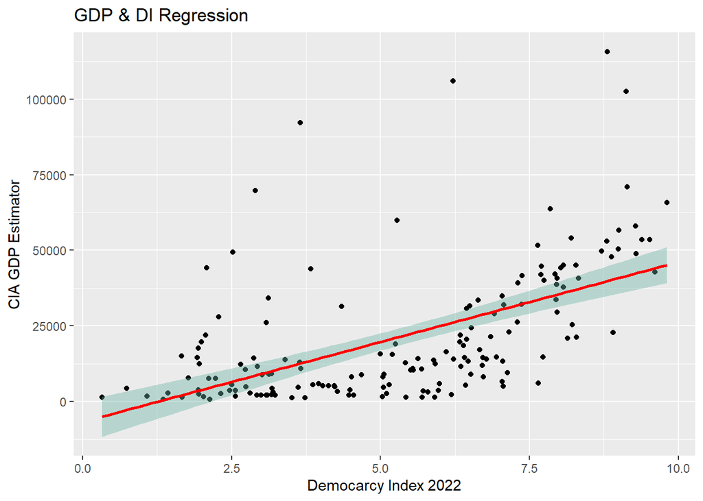

```r
# Create a scatter plot of DI & GDP
DI_GDP_scatter_plot <- ggplot(DF_helper, aes(x=X2022, y=New_CIA_Estimate)) +
  geom_point() +
  geom_smooth(method=lm , color="red", fill="#69b3a2", se=TRUE) +
  labs(x = "Democarcy Index 2022", y = "CIA GDP Estimator", title = "GDP & DI Regression")

# Display the plot
DI_GDP_scatter_plot
```

First of all, we can see that for countries with ~ 1.27 (approx.) Democracy index or lower, we get a negative GDP value estimator.

If we will dug deeper, we can notice that there is a positive connection between the Democracy index and the GDP (The regression intercept is not statistically significant).

```r
# Create a new mini DF for the two columns
DF_helper_2 <- DF_merged[,c("Crime_Rate_per_100k", "X2022")]
DF_helper_2 <- na.omit(DF_helper_2)

# change form a "characters" variables to "double" variables
DF_helper_2$New_Crime_Rate_per_100k <- as.numeric(DF_helper_2$Crime_Rate_per_100k)

# Create the linear regression for DI & Crime
DI_Crime_Reg <- lm(New_Crime_Rate_per_100k~X2022,data = DF_helper_2)
summary(DI_Crime_Reg)
```

```
##
## Call:
## lm(formula = New_Crime_Rate_per_100k ~ X2022, data = DF_helper_2)
##
## Residuals:
##     Min      1Q  Median      3Q     Max
## -132.92  -81.94  -36.21   39.75  450.53
##
## Coefficients:
##             Estimate Std. Error t value Pr(>|t|)
## (Intercept) 158.2880    22.3276   7.089 4.01e-11 ***
## X2022        -0.7536     3.7828  -0.199    0.842
## ---
## Signif. codes:  0 '***' 0.001 '**' 0.01 '*' 0.05 '.' 0.1 ' ' 1
##
## Residual standard error: 113.6 on 161 degrees of freedom
## Multiple R-squared:  0.0002465,  Adjusted R-squared:  -0.005963
## F-statistic: 0.03969 on 1 and 161 DF,  p-value: 0.8423
```

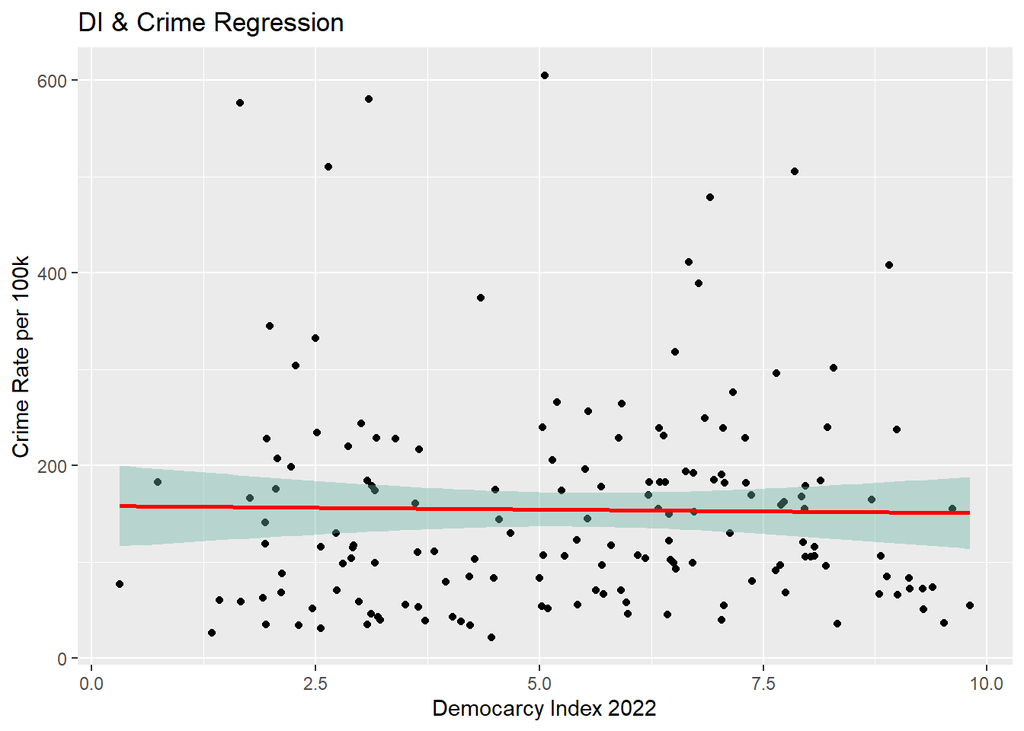

```r
# Create a scatter plot of DI & Crime
DI_Crime_scatter_plot <- ggplot(DF_helper_2, aes(x=X2022, y=New_Crime_Rate_per_100k)) +
  geom_point() +
  geom_smooth(method=lm , color="red", fill="#69b3a2", se=TRUE) +
  labs(x = "Democarcy Index 2022", y = "Crime Rate per 100k", title = "DI & Crime Regression")

DI_Crime_scatter_plot
```

We may want to infer that there isn’t a significant connection between the country’s democracy level to the relative number of crimes in it, but the regression coefficient is not statistically significant so we can not assume that for sure.

### Empirical Cumulative Distribution Function (CDF):

**6.a.**

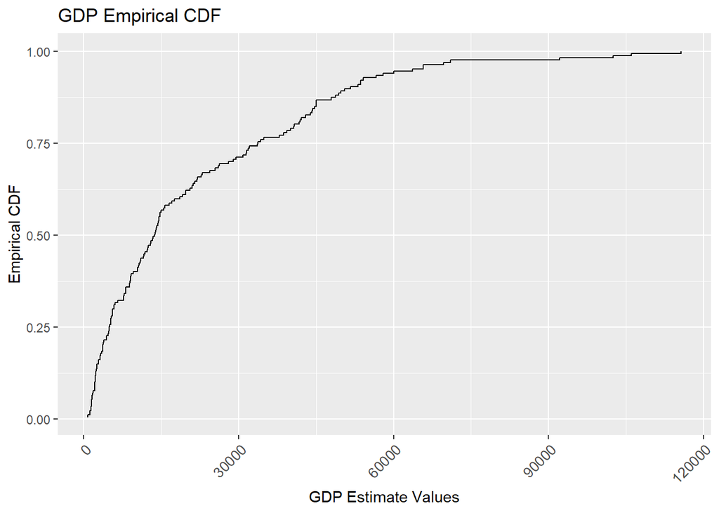

```r
# Create a copied vector and then sorting it
CIA_Estimates <- DF_helper$New_CIA_Estimate
Sorted_CIA_Estimates <- sort(CIA_Estimates)
n <- length(Sorted_CIA_Estimates)
# Create the empirical CDF
Empirical_CIA_CDF <- (1:n) / n

DF_CDF <- data.frame(x = Sorted_CIA_Estimates, cdf = Empirical_CIA_CDF)

# Visualize the CDF plot
GDP_CDF_Plot <- ggplot(DF_CDF, aes(x = Sorted_CIA_Estimates, y = Empirical_CIA_CDF)) +
  geom_step() +
  labs(x = "GDP Estimate Values", y = "Empirical CDF", title = "GDP Empirical CDF") +
  theme(axis.text.x = element_text(angle = 45, hjust = 1, size = 10))

GDP_CDF_Plot
```

**6.b.**

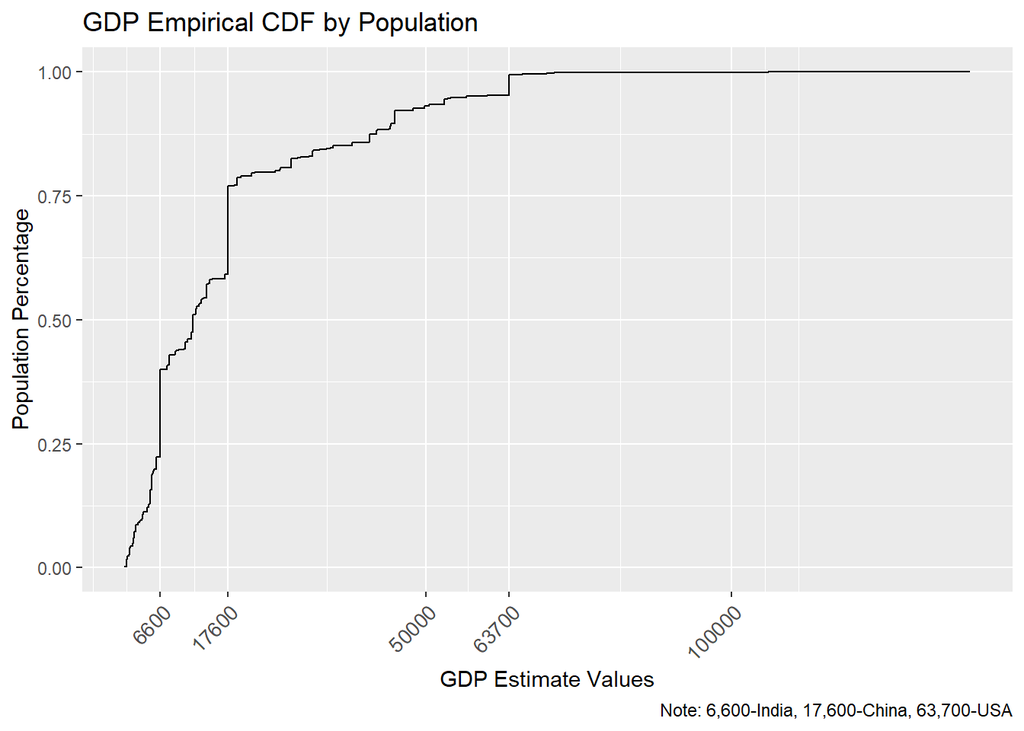

```r
# Create a new mini DF for the two columns
DF_GDP_Pop <- DF_merged[,c("Pop_Number", "CIA_Estimate")]
DF_GDP_Pop <- na.omit(DF_GDP_Pop)

# change form a "characters" variables to "double" variables
DF_GDP_Pop$New_CIA_Estimate_2 <- as.numeric(gsub(",", "", DF_GDP_Pop$CIA_Estimate))
DF_GDP_Pop$New_Pop_Number <- as.numeric(gsub(",", "", DF_GDP_Pop$Pop_Number))

# sorting the data by GDP Estimate
DF_GDP_Pop <- DF_GDP_Pop[order(DF_GDP_Pop$New_CIA_Estimate_2),]
DF_GDP_Pop <- DF_GDP_Pop[DF_GDP_Pop$Pop_Number != "8,032,932,000",]

# Create the empirical CDF for pop & GDP
DF_GDP_Pop$Empirical_CIA_CDF_Pop <- DF_GDP_Pop$New_Pop_Number / (sum(DF_GDP_Pop$New_Pop_Number))
DF_GDP_Pop$Cum_Empirical_CIA_CDF_Pop <- cumsum(DF_GDP_Pop$Empirical_CIA_CDF_Pop)

# Visualize the CDF plot for pop & GDP
GDP_Pop_CDF_Plot <- ggplot(DF_GDP_Pop, aes(x = New_CIA_Estimate_2, y = Cum_Empirical_CIA_CDF_Pop)) +
  geom_step() +
  labs(x = "GDP Estimate Values", y = "Population Percentage", title = "GDP Empirical CDF by Population", caption = "Note: 6,600-India, 17,600-China, 63,700-USA") +
  #theme_minimal()
  scale_x_continuous(labels = function(x) format(x, scientific = FALSE), breaks = c(6600,17600,50000,63700,100000))+
  theme(legend.position = "right", axis.text.x = element_text(angle = 45, hjust = 1, size = 10))

GDP_Pop_CDF_Plot
```

The differences between this distribution and the former are because now we take under consideration the relative part of a specific country population from the entire world, while before we just selected a country randomly, assuming the probabilities are equal. This distribution is more realistic and accurate, we also can see the big jumps in high population countries like China, India & USA.

**6.c.**

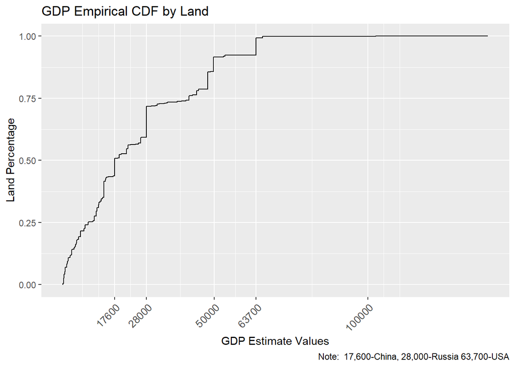

```r
# YOUR CODE HERE
# Create a new mini DF for the two columns
DF_GDP_Land <- DF_merged[,c("Land_skm", "CIA_Estimate")]
DF_GDP_Land <- na.omit(DF_GDP_Land)

# change form a "characters" variables to "double" variables
DF_GDP_Land$New_CIA_Estimate_3 <- as.numeric(gsub(",", "", DF_GDP_Land$CIA_Estimate))
DF_GDP_Land$New_Land_skm <- as.integer(gsub(",", "", DF_GDP_Land$Land_skm))

# sorting the data by GDP Estimate
DF_GDP_Land <- DF_GDP_Land[order(DF_GDP_Land$New_CIA_Estimate_3),]
DF_GDP_Land <- DF_GDP_Land[DF_GDP_Land$Land_skm != "148,940,000",]
DF_GDP_Land <- DF_GDP_Land[DF_GDP_Land$Land_skm != "",]

# Create the empirical CDF for pop & GDP
DF_GDP_Land$Empirical_CIA_CDF_Land <- DF_GDP_Land$New_Land_skm / (sum(DF_GDP_Land$New_Land_skm))
DF_GDP_Land$Cum_Empirical_CIA_CDF_Land <- cumsum(DF_GDP_Land$Empirical_CIA_CDF_Land)

# Visualize the CDF plot for pop & GDP
GDP_Land_CDF_Plot <- ggplot(DF_GDP_Land, aes(x = New_CIA_Estimate_3, y = Cum_Empirical_CIA_CDF_Land)) +
  geom_step() +
  labs(x = "GDP Estimate Values", y = "Land Percentage", title = "GDP Empirical CDF by Land", caption = "Note:  17,600-China, 28,000-Russia 63,700-USA") +
  scale_x_continuous(labels = function(x) format(x, scientific = FALSE), breaks = c(17600,28000,50000,63700,100000))+
  theme(legend.position = "right", axis.text.x = element_text(angle = 45, hjust = 1, size = 10))

GDP_Land_CDF_Plot
```

The differences between this distribution and the former are because now we take under consideration the relative part of a the country land area from the entire world, while before we just selected a country randomly, assuming the probabilities are equal. This distribution is more realistic and accurate (as well as b), we also can see the big jumps in high land area countries like China, Russia & USA.

```r
# Extracting the quantails for each section
GDP_0.25 <- max(DF_CDF$x[DF_CDF$cdf <= 0.25])
GDP_Median <- max(DF_CDF$x[DF_CDF$cdf <= 0.5])
GDP_0.75 <- max(DF_CDF$x[DF_CDF$cdf <= 0.75])

Pop_0.25 <- max(DF_GDP_Pop$New_CIA_Estimate_2[DF_GDP_Pop$Cum_Empirical_CIA_CDF_Pop <= 0.25])
Pop_Median <- max(DF_GDP_Pop$New_CIA_Estimate_2[DF_GDP_Pop$Cum_Empirical_CIA_CDF_Pop <= 0.5])
Pop_0.75 <- max(DF_GDP_Pop$New_CIA_Estimate_2[DF_GDP_Pop$Cum_Empirical_CIA_CDF_Pop <= 0.75])

Land_0.25 <- max(DF_GDP_Land$New_CIA_Estimate_3[DF_GDP_Land$Cum_Empirical_CIA_CDF_Land <= 0.25])
Land_Median <- max(DF_GDP_Land$New_CIA_Estimate_3[DF_GDP_Land$Cum_Empirical_CIA_CDF_Land <= 0.5])
Land_0.75 <- max(DF_GDP_Land$New_CIA_Estimate_3[DF_GDP_Land$Cum_Empirical_CIA_CDF_Land <= 0.75])

# Display a DF for all quantiles
all_quantails <- c(GDP_0.25,Land_0.25,Pop_0.25,GDP_Median,Land_Median,Pop_Median,GDP_0.75,Land_0.75,Pop_0.75)
all_quantails_mat <- matrix(all_quantails, nrow = 3, ncol = 3, byrow = TRUE)
DF_all_quantails <- as.data.frame(all_quantails_mat)
rownames(DF_all_quantails) <- c("Q-25", "Median", "Q-75")
colnames(DF_all_quantails) <- c("GDP", "Land", "Pop")
DF_all_quantails
```

|  | GDP | Land | Pop |
| --- | --- | --- | --- |
| Q-25 | 4900 | 9100 | 6100 |
| Median | 13400 | 17100 | 11700 |
| Q-75 | 33600 | 41700 | 17100 |

All the quantiles are different.

For the first column (section a), there won’t be any special results because the countries are selected uniformly.

In the second column, when we calculate by land, the first quantile is bigger, which means that countries with relatively small land will have a relatively smaller GDP (because a lot more countries got under this quantile). In the median, we can experience something a bit odd, when a country in the 43.8 quantile represent the median, that is bacause the next country is China that make a jump straight to 50.08 quantile.

In the third column, when we calculate by population the first quantile is bigger but the median is acttualy smaller than the first column. That is because of India that have a very large population number but relatively small GDP (it caused a jump from the 0.22 quantile straight to the 39.99 quantile).

### Displaying data on the world map:

**7.**

```r
# Load the world map data
data("countryExData")

#change the two specific country names
DF_Countries$Country[DF_Countries$Country == " North Macedonia"] <- "Macedonia"
DF_Countries$Country[DF_Countries$Country == "Eswatini"] <- "Swaziland"

# Create a new mini DF
DF_World<- DF_Countries[,c("Country", "AVG_Index")]

# Join with country data
WorldMap <- joinCountryData2Map(DF_World,countryExData, joinCode = "NAME", nameJoinColumn = "Country")
```

```
## 166 codes from your data successfully matched countries in the map
## 1 codes from your data failed to match with a country code in the map
## 77 codes from the map weren't represented in your data
```

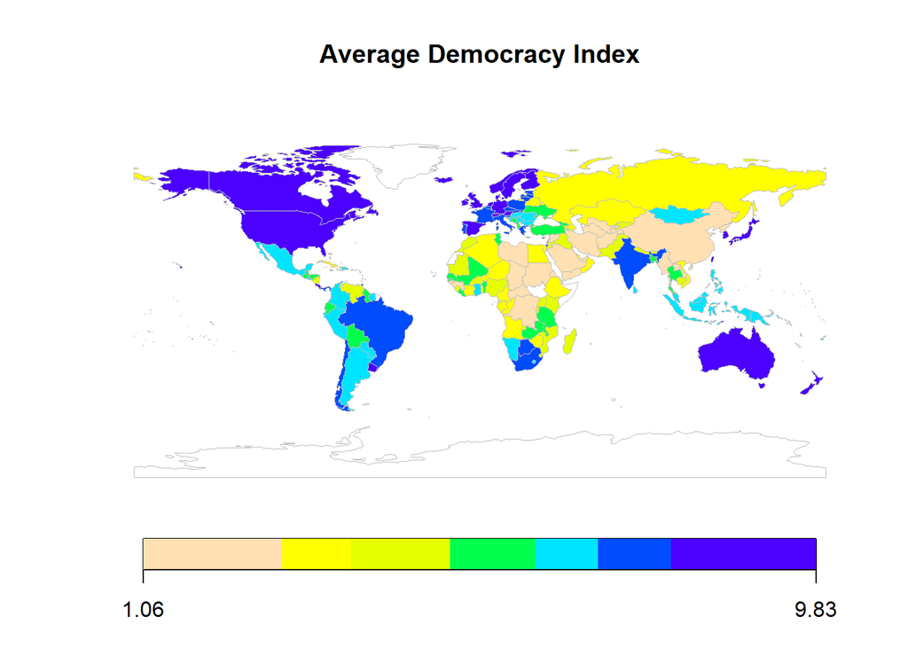

```r
# Display the world map
mapCountryData(WorldMap, nameColumnToPlot = "AVG_Index", catMethod = "quantiles", mapTitle = "Average Democracy Index", colourPalette = "topo", addLegend = TRUE)
```

As can be seen from the map, we can see that the most democratic continents are North America, Australia & Europe. The less democratic continent is Asia (excluding India & Japan). The most undemocratic countries in Asia are in the middle east (excluding Israel). Africa is the most diverse continent democracy index wise.

```r
DF_Countries$diff <- DF_Countries$X2022 - DF_Countries$X2006

# Create a new mini DF
DF_World_2<- DF_Countries[,c("Country", "diff")]

# Join with country data
WorldMap <- joinCountryData2Map(DF_World_2,countryExData, joinCode = "NAME", nameJoinColumn = "Country")
```

```
## 166 codes from your data successfully matched countries in the map
## 1 codes from your data failed to match with a country code in the map
## 77 codes from the map weren't represented in your data
```

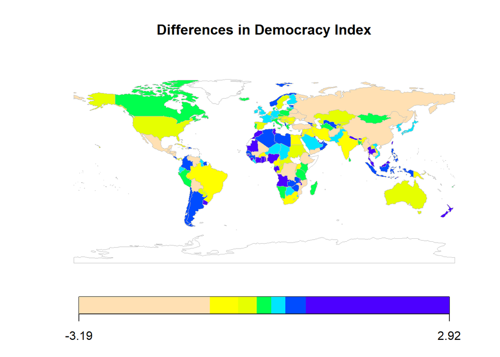

```r
# Display the world map
mapCountryData(WorldMap, nameColumnToPlot = "diff", catMethod = "quantiles", mapTitle = "Differences in Democracy Index", colourPalette = "topo", addLegend = TRUE)
```

As can be seen from this map, we can infer that overall democracy in the entire world is getting weaker and weaker. An exception is Africa, the democracy index there gone higher. But overall, this map colors are much more lighter than the previous map, so we can see that the democracy index for most countries has gone down in the past 16 years, an alarming trend.

### Coponents of the Demography Index:

**8.a.**

```r
# Merging the data
DF_merged <- merge(DF_merged, DF_Components, by = "Country", all = TRUE)

# Display the top rows
head(DF_merged)
```

|  | Country | Region.x | X2022.rank | Regime.type.x | X2022 | X2021 | X2020 | X2019 | X2018 | X2017 | X2016 | X2015 | X2014 | X2013 | X2012 | X2011 | X2010 | X2008 | X2006 | AVG_Index | Cluster | Minimum_DI | Maximum_DI | Regime.type.2006 | UN.Region | IMF_Estimate | IMF_Year | World_Bank_Estimate | World_Bank_Year | … |
| --- | --- | --- | --- | --- | --- | --- | --- | --- | --- | --- | --- | --- | --- | --- | --- | --- | --- | --- | --- | --- | --- | --- | --- | --- | --- | --- | --- | --- | --- | --- |
| 1 | Abkhazia | NA | NA | NA | NA | NA | NA | NA | NA | NA | NA | NA | NA | NA | NA | NA | NA | NA | NA | NA | NA | NA | NA | NA | NA | NA | NA | NA | NA | … |
| 2 | Afghanistan | Asia and Australasia | 167 | Authoritarian | 0.32 | 0.32 | 2.85 | 2.85 | 2.97 | 2.55 | 2.55 | 2.77 | 2.77 | 2.48 | 2.48 | 2.48 | 2.48 | 3.02 | 3.06 | 2.397 | Large Decrease | 0.32 | 3.06 | Authoritarian | Asia | 2,456 | 2020 | 1,666 | 2021 | … |
| 3 | Akrotiri and Dhekelia | NA | NA | NA | NA | NA | NA | NA | NA | NA | NA | NA | NA | NA | NA | NA | NA | NA | NA | NA | NA | NA | NA | NA | NA | NA | NA | NA | NA | … |
| 4 | Åland | NA | NA | NA | NA | NA | NA | NA | NA | NA | NA | NA | NA | NA | NA | NA | NA | NA | NA | NA | NA | NA | NA | NA | NA | NA | NA | NA | NA | … |
| 5 | Albania | Central and Eastern Europe | 64 | Flawed democracy | 6.41 | 6.11 | 6.08 | 5.89 | 5.98 | 5.98 | 5.91 | 5.91 | 5.67 | 5.67 | 5.67 | 5.81 | 5.86 | 5.91 | 5.91 | 5.918 | Other | 5.67 | 6.41 | Hybrid regime | Europe | 19,029 | 2023 | 15,709 | 2021 | … |
| 6 | Algeria | Middle East and North Africa | 113 | Authoritarian | 3.66 | 3.77 | 3.77 | 4.01 | 3.50 | 3.56 | 3.56 | 3.95 | 3.83 | 3.83 | 3.83 | 3.44 | 3.44 | 3.32 | 3.17 | 3.643 | Other | 3.17 | 4.01 | Authoritarian | Africa | 13,507 | 2023 | 12,128 | 2021 | … |

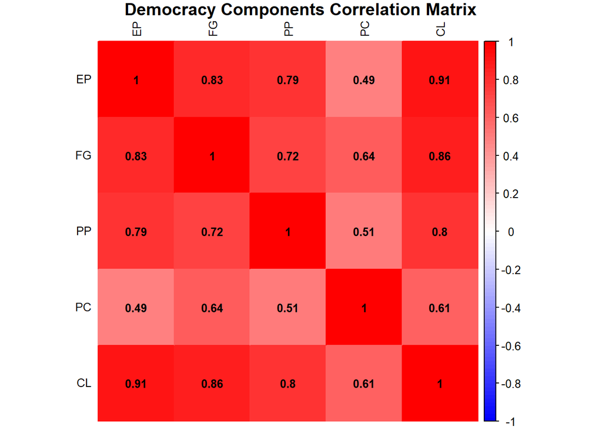

```r
DF_Democracy_Components <- data.frame(DF_Components[6:10])
DC_corr_mat <- cor(DF_Democracy_Components)

# Create columns and row shortcuts names
colnames(DC_corr_mat) <- c("EP", "FG", "PP", "PC", "CL")
rownames(DC_corr_mat) <- c("EP", "FG", "PP", "PC", "CL")

# Display the cor matrix
corrplot(DC_corr_mat, method = "color",col = colorRampPalette(c("blue", "white", "red"))(100),
         tl.col = "black",
         tl.srt = 90,
         tl.cex = 0.8,
         addCoef.col = "black",
         number.cex = 0.8,
         main = "Democracy Components Correlation Matrix",
         cex.main = 1.2,
         mar = c(0, 0, 1, 0))
```

**8.b.**

```r
# Create a mini DF for the relevant varriables
DF_helper_4 <- DF_merged[,c("Country","CIA_Estimate","Electoral_Process_and_Pluralism","Functioning_of_Government","Political_Participation","Political_Culture","Civil_Liberties")]

# Remove NA's and clean the data
DF_helper_4 <- na.omit(DF_helper_4)
DF_helper_4$CIA_Estimate <- as.numeric(gsub(",", "", DF_helper_4$CIA_Estimate))

# Create the regression
Comp_Reg <- lm(DF_helper_4$CIA_Estimate~DF_helper_4$Electoral_Process_and_Pluralism+DF_helper_4$Functioning_of_Government+DF_helper_4$Political_Participation+DF_helper_4$Political_Culture+DF_helper_4$Civil_Liberties)

# Display regression results
summary(Comp_Reg)
```

```
##
## Call:
## lm(formula = DF_helper_4$CIA_Estimate ~ DF_helper_4$Electoral_Process_and_Pluralism +
##     DF_helper_4$Functioning_of_Government + DF_helper_4$Political_Participation +
##     DF_helper_4$Political_Culture + DF_helper_4$Civil_Liberties)
##
## Residuals:
##    Min     1Q Median     3Q    Max
## -33232  -9248  -2115   7528  66780
##
## Coefficients:
##                                             Estimate Std. Error t value
## (Intercept)                                 -16119.7     4524.9  -3.562
## DF_helper_4$Electoral_Process_and_Pluralism  -2990.1      888.6  -3.365
## DF_helper_4$Functioning_of_Government         4905.0     1033.2   4.747
## DF_helper_4$Political_Participation            719.7     1078.9   0.667
## DF_helper_4$Political_Culture                 2722.1      919.9   2.959
## DF_helper_4$Civil_Liberties                   2319.3     1319.1   1.758
##                                             Pr(>|t|)
## (Intercept)                                 0.000484 ***
## DF_helper_4$Electoral_Process_and_Pluralism 0.000957 ***
## DF_helper_4$Functioning_of_Government       4.52e-06 ***
## DF_helper_4$Political_Participation         0.505687
## DF_helper_4$Political_Culture               0.003552 **
## DF_helper_4$Civil_Liberties                 0.080608 .
## ---
## Signif. codes:  0 '***' 0.001 '**' 0.01 '*' 0.05 '.' 0.1 ' ' 1
##
## Residual standard error: 16390 on 161 degrees of freedom
## Multiple R-squared:  0.4739, Adjusted R-squared:  0.4575
## F-statistic:    29 on 5 and 161 DF,  p-value: < 2.2e-16
```

```r
# The coefficients with significant level of 0.01
Sig_Coeff <- summary(Comp_Reg)$coefficients[summary(Comp_Reg)$coefficients[, "Pr(>|t|)"] < 0.01, ]

Sig_Coeff_p_values <- summary(Comp_Reg)$coefficients[, "Pr(>|t|)"]

# Create a table with significant coefficients names and p-values
significant_coeffs_table <- data.frame(P_Value = Sig_Coeff_p_values[Sig_Coeff_p_values < 0.01])

# Display the table
options(scipen = 999)
significant_coeffs_table
```

|  | P_Value |
| --- | --- |
| (Intercept) | 0.000483523505 |
| DF_helper_4$Electoral_Process_and_Pluralism | 0.000957040098 |
| DF_helper_4$Functioning_of_Government | 0.000004524371 |
| DF_helper_4$Political_Culture | 0.003551962443 |

```r
# Calculate 5 countries with the highest and lowest residuals
Com_Reg_residuals <- rstandard(Comp_Reg)
top5_Com_Reg_residuals <- DF_helper_4[order(Com_Reg_residuals, decreasing = TRUE), ][1:5, ]
bottom5_Com_Reg_residuals <- DF_helper_4[order(Com_Reg_residuals), ][1:5, ]

# Display the top & bottom 5 countries
top5_Com_Reg_residuals
```

|  | Country | CIA_Estimate | Electoral_Process_and_Pluralism | Functioning_of_Government | Political_Participation | Political_Culture | Civil_Liberties |
| --- | --- | --- | --- | --- | --- | --- | --- |
| 145 | Luxembourg | 115700 | 10.00 | 8.93 | 6.67 | 8.75 | 9.71 |
| 200 | Qatar | 92200 | 1.50 | 4.29 | 3.33 | 5.63 | 3.53 |
| 225 | Singapore | 106000 | 4.83 | 7.86 | 4.44 | 7.50 | 6.47 |
| 120 | Ireland | 102500 | 10.00 | 8.21 | 8.33 | 10.00 | 9.12 |
| 264 | United Arab Emirates | 69700 | 0.00 | 4.29 | 2.22 | 5.63 | 2.35 |

```r
bottom5_Com_Reg_residuals
```

|  | Country | CIA_Estimate | Electoral_Process_and_Pluralism | Functioning_of_Government | Political_Participation | Political_Culture | Civil_Liberties |
| --- | --- | --- | --- | --- | --- | --- | --- |
| 28 | Benin | 3300 | 1.67 | 5.71 | 3.33 | 6.25 | 4.41 |
| 47 | Cape Verde | 6100 | 9.17 | 7.00 | 6.67 | 6.88 | 8.53 |
| 268 | Uruguay | 22800 | 10.00 | 8.93 | 7.78 | 8.13 | 9.71 |
| 131 | Kenya | 4700 | 3.50 | 5.36 | 6.67 | 5.63 | 4.12 |
| 192 | Papua New Guinea | 3700 | 6.92 | 6.07 | 3.89 | 5.63 | 7.35 |

For the top 5 countries, factors that leads to high GDP can be economic policies (fiscal and monetary policies, tax rates, trade regulations and so on), natural resources, international trade and macroeconomic factors.

For the bottom 5 countries, factors that leads to low GDP can be environmental challenges, economic challenges such as high levels of unemployment & inflation and underdeveloped technology industry.